# upload_zxlplbdyogulgfzoidlu765mqg.pdf

Methodological Report on Data Auditing, Cleaning, and Imputation

–

Retail

Store Sales

Author:

John Jairo Prado

Mahmoud Gamil

Fuente:

https://www.kaggle.com/code/mahmoudredagamail/retail

-

store

-

sales

-

dirty

-

for

-

data

-

cleaning

1.

Introduction

The project uses the Retail Store Sales: Dirty for Data Cleaning dataset, which

consists of 12,575 transactions and 11 variables related to customers, products,

categories,

prices,

quantities,

total

spending,

payment

methods,

locations,

transaction dates,

and discount application. The dataset was designed to contain

data quality issues, providing an opportunity to develop a systematic process for

data auditing, cleaning, and imputation.

Data

processing

was

divided

into

two

stages.

First,

a

data

quality

audit

and

deterministic cleaning based on business rules were performed using Python.

Subsequently, R was used to assess missing values that could not be recovered

exactly and determine whi

ch could be addressed through statistical imputation

methods.

The

methodological

approach

focused

on

preserving

the

original

data

and

modifying values only when a validated deterministic rule or sufficient statistical

evidence supported the imputation.

2. Initial Dataset Structure

The Retail Store Sales: Dirty for Data Cleaning dataset consists of 12,575 records

and

11

variables

containing

information

about

retail

transactions,

including

customer and transaction identifiers, product categories, purchased items, unit

prices,

quantiti

es

sold,

total

spending,

payment

methods,

locations,

purchase

dates, and discount application.

The

variables

were

classified

according

to

their

function

into

two

identifiers

(Transaction

ID

and

Customer ID), four categorical variables

(Category,

Item,

Payment

Method,

and

Location),

three

numerical

variables

(Price

Per

Unit,

Quantity, and Total Spent

), one temporal variable (Transaction Date), and one

binary

variable

(Discount

Applied).

This

classification

helped

identify

the

characteristics of the data and establish appropriate validation criteria for each

variable type.

The

three

numerical

variables

describe

the

economic

components

of

the

transactions

and

allow

an

assessment

of

the

consistency

between

unit

price,

quantity

purchased,

and

total

spending.

This

relationship

facilitates

the

identification

of

inconsistencies

an

d

the

recovery

of

certain

missing

values

through

business

rules,

provided

that

the

relationships

between

variables

are

verified and the potential effect of discounts on the recorded transaction amount

is considered.

The Transaction Date variable was initially stored as text and was subsequently

converted to a date format to facilitate temporal analysis. The Discount Applied

variable indicates whether a discount was applied and requires a consistency

check of its encod

ing, as it initially contained Boolean or text values.

The review of this structure helped establish the initial criteria for the data quality

audit, identify relationships that could be used in deterministic data cleaning, and

distinguish

values

recoverable

through

verifiable

rules

from

those

requiring

statis

tical assessment before imputation could be considered.

| Variable | Initial type | Description |
| --- | --- | --- |
| Transaction ID | Text | Transaction identifier |
| Customer ID | Text | Customer identifier |
| Category | Text | Product category |
| Item | Text | Purchased product |
| Price Per Unit | Numeric | Unit price |
| Quantity | Numeric | Quantity purchased |
| Total Spent | Numeric | Total amount spent |
| Payment Method | Text | Payment method used |
| Location | Text | Purchase channel or location |
| Transaction Date | Text | Transaction date |
| Discount Applied | Boolean-Text | I ndicates whether a discount was applied |

Table 1.

Dataset variables

Source.

https://www.kaggle.com/code/mahmoudredagamail/retail

-

store

-

sales

-

dirty

-

for

-

data

-

cleaning

Table 1 presents the dataset structure, consisting of 12,575 observations and 11

variables

classified

according

to

their

function

as

identifiers,

categorical,

numerical,

temporal,

and

binary

variables.

The

dataset

primarily

contains

transactional and categ

orical information. Among the numerical variables, Price

Per Unit, Quantity, and Total Spent allow the consistency of recorded purchase

amounts to be assessed and relationships to be established for data validation.

The

Transaction

Date

variable

was

initially

stored

as

text

and

subsequently

converted to a date format to facilitate temporal analysis. Overall, this structure

supports

the

ide

ntification

of

potential

inconsistencies

and

the

application

of

business rules for data cleaning and missing value recovery, provided that the

underlying relationships have been verified.

3. Initial Missing Data Assessment

The initial data quality audit identified five variables with missing values, revealing

differences in the completeness levels of the recorded information.

| Variable | Missing Values | Percentage |
| --- | --- | --- |
| Discount Applied | 4.199 | 33,39 % |
| Item | 1.213 | 9,65 % |
| Price Per Unit | 609 | 4,84 % |
| Quantity | 604 | 4,80 % |
| Total Spent | 604 | 4,80 % |

Tabl

e

2.

Missing Values Before Cleaning

Source.

Prepared by the author.

Table 2 presents the distribution of missing values across five variables in the

original dataset. Discount Applied has the highest proportion of missing data, with

4,199

observations

(33.39%),

followed

by

Item,

with

1,213

(9.65%).

The

numerical variables

Price Per Unit, Quantity, and Total Spent have missing data

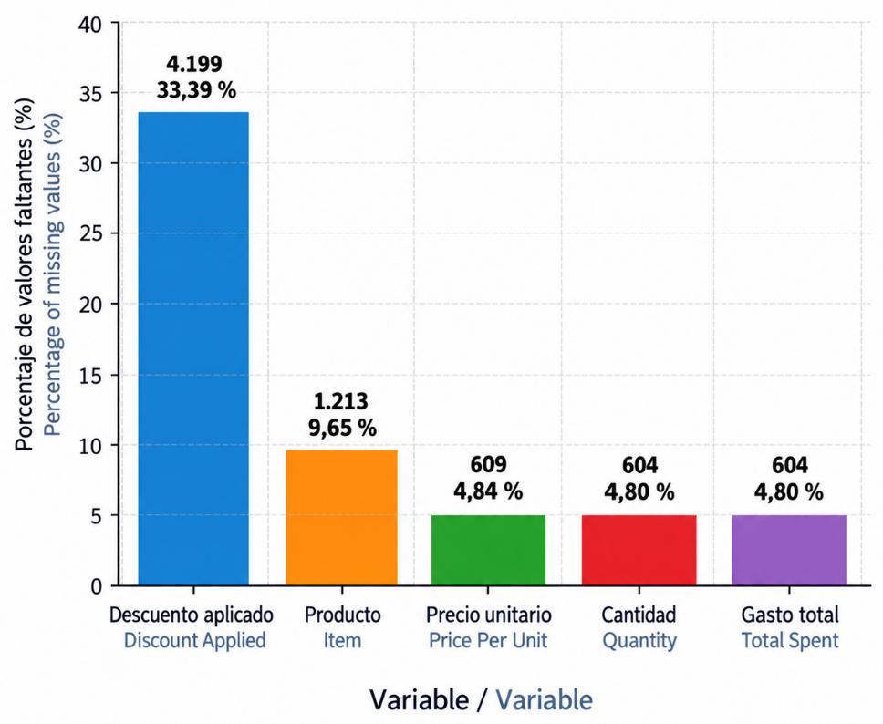

percentages close to 5%. The identical count of 604 missing values in Quantity

and

Total

Spent

suggests

a

possible

shared

missingness

pattern,

although

further verification is required to determine whether these values occur in the

same transactions. These

findings identify the main data completeness issues

and

guide

the

subsequent

analysis

of

missingness

patterns

before

selecting

appropriate recovery and imputation procedures.

Figure 1

.

Distribution of Missing Values by Variable in the Original Dataset.

Source.

Prepared by the author.

Figure

1

presents

the

number

and

percentage

of

missing

values

across

five

variables

in

the

original

dataset,

which

contains

12,575

transactions.

The

Discount Applied variable has the highest proportion of missing data, with 4,199

observations

(33.39%),

followed

by

Item,

with

1,213

(9.65%).

The

numerical

variables

Price

Per

Unit,

Quantity,

and

Total

Spent

show

considerably

lower

percentages,

ranging

from

4.80%

to

4.84%.

In

particular,

Quantity

and

Total

Spent

each

contain

604

missing

values,

suggesting

a

possible

shared

missingness pattern. However, this coincidence alone does not confirm that the

missing values occur in the same transactions. These findings reveal differences

in

data

completen

ess

across

variables

and

provide

a

basis

for

examining

missingness

patterns

before

applying

deterministic

recovery

procedures

or

statistical imputation methods.

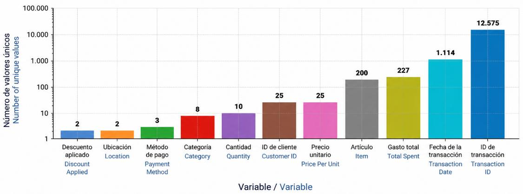

4.

Cardinality of the variables

The number of distinct values contained in each variable was also studied.

| Variable | Unique Values |
| --- | --- |
| Discount Applied | 2 |
| Location | 2 |
| Payment Method | 3 |
| Category | 8 |
| Quantity | 10 |
| Customer ID | 25 |
| Price Per Unit | 25 |
| Item | 200 |
| Total Spent | 227 |
| Transaction Date | 1.114 |
| Transaction ID | 12.575 |

Table 3.

Number of Unique Values by Variable in the Original Dataset.

Source.

Prepared by the author.

Table 3 presents the number of unique values identified in each variable of the

original

dataset.

Transaction

ID

contains

12,575

distinct

values,

matching

the

total number of transactions and indicating that there are no duplicate transaction

identifiers.

In contrast, Customer ID contains 25 distinct identifiers, while Item

includes

200

products

and

Category

comprises

8

categories.

Both

Discount

Applied

and

Location

have

two

unique

values,

whereas

Payment

Method

contains three. Among the numerical variables

, Quantity has 10 distinct values,

Price

Per

Unit

has

25,

and

Total

Spent

has

227.

Finally,

Transaction

Date

contains

1,114

distinct

dates.

These

findings

provide

an

overview

of

variable

cardinality, help identify potential coding inconsistencies, and guide the validation

procedures required during data cleaning. However, the number of unique values

alone is insufficient to determine whether the recorded categories or values are

valid.

Figure 2.

Number of Unique Values by Variable in the Original Dataset.

Source.

Prepared by the author.

Figure

2

shows the number of unique values recorded for each variable, using a

logarithmic

scale

to

facilitate

comparisons

across

variables

with

different

cardinality levels. Transaction ID contains 12,575 distinct values, matching the

total number of records, while Transaction Date includes 1,114 unique dates.

Among the purchase

-

related variables, Total Spent has 227 unique values, Item

contains 200, and bo

th Price Per Unit and Customer ID have 25 each. Meanwhile,

Quantity

contains

10

distinct

values

and

Category

has

8,

whereas

Payment

Method, Location, and Discount Applied show lower diversity, with 3, 2, and 2

values, respectively. This distribution highli

ghts differences in variable cardinality

and

helps

guide

the

identification

of

potential

inconsistencies

during

data

cleaning. However, the number of unique values alone is insufficient to establish

data

validity

or

rule

out

duplicate

records

based

on

othe

r

combinations

of

variables.

5. Validation of the Quantity domain

Quantity represents the number of units purchased.

| Quantity | Frequency |
| --- | --- |
| 1 | 1.147 |
| 2 | 1.164 |
| 3 | 1.224 |
| 4 | 1.155 |
| 5 | 1.228 |
| 6 | 1.220 |
| 7 | 1.227 |
| 8 | 1.226 |
| 9 | 1.148 |
| 10 | 1.232 |
| Missing item | 604 |

Table 4.

F

requency Distribution of the Number of Units

Purchased per

Transaction in the Original Dataset.

Source.

Prepared by the author.

Table

4

presents

the

frequency

distribution

of

the

Quantity

variable,

which

represents

the

number

of

units

purchased

per

transaction.

Observed

values

range from 1 to 10 units, with relatively similar frequencies. Transactions involving

10

units

have

the

hi

ghest

frequency,

with

1,232

records,

while

transactions

involving

one

unit

have

the

lowest,

with

1,147.

This

difference

of

85

records

indicates a relatively uniform distribution across the observed quantities, with no

pronounced

concentration

at

any

particular

value.

Additionally,

604

missing

observations

were

identified

(4.80%

of

th

e

dataset).

Recovering

these

values

requires assessing their relationships with other variables, particularly Price Per

Unit and Total Spent, before considering statistical imputation procedures.

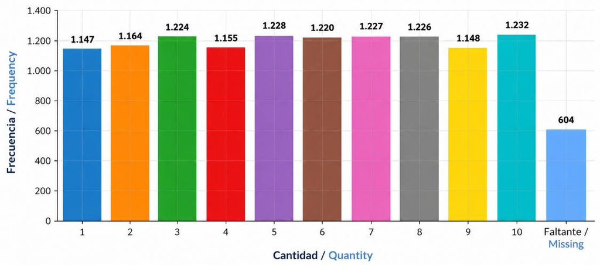

Figure 3.

Frequency Distribution of the Number of Units Purchased per

Transaction in the Original Dataset.

Source.

Prepared by the author.

Figure

3

presents

the

frequency

distribution

of

the

Quantity

variable,

with

observed

values ranging from 1 to 10 units per transaction. The frequencies show a relatively

uniform pattern, ranging from 1,147 to 1,232 records. Purchases of 10 units have the

highest f

requency, with 1,232 transactions, while purchases of one unit have the lowest,

with

1,147. The difference of 85 observations indicates no pronounced concentration at

any particular quantity. Additionally, 604 records contain missing values (4.80% of the

dataset), limiting a complete analysis of purchased quantities. These findings provid

e a

reference

for

subsequently

evaluating

the

distribution

of

Quantity

and

determining

whether recovery or imputation procedures alter its original characteristics.

6.

Price Per Unit Validation

Exactly 25 different price levels were found, ranging from 5.0 to 41.0.

| Indicator | Value |
| --- | --- |
| Minimum price | 5,0 |
| Maximum price | 41,0 |
| Number of distinct prices | 25 |
| Missing values | 609 |
| Values outside the expected range | 0 |

Table 5.

Data Quality Indicators and Characteristics of the Price Per Unit

Variable in the Original Dataset.

Source.

Prepared by the author.

Table

5

presents

the

results

of

the

initial

assessment

of

the

Price

Per

Unit

variable, which represents the unit price of purchased products. Observed values

range from 5.0 to 41.0, with 25 distinct prices and no records outside the expected

range. However

, 609 missing values were identified, accounting for 4.84% of the

12,575

transactions.

Although

the

recorded

prices

fall

within

the

established

validation limits, missing information affects the completeness of this variable.

These

findings

help

guide

the

recovery

of

unit

prices

through

verifiable

relationships with other variables, particularly Item, Quantity, and Total Spent,

before considering statistical imputation methods.

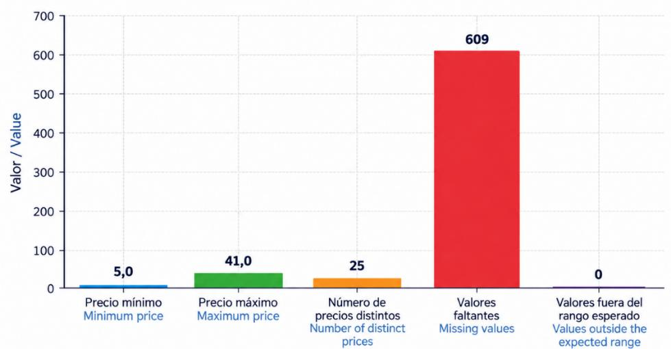

Figure 4.

Summary of Data Quality Indicators for the Price Per Unit Variable in

the Original Dataset.

Source.

Prepared by the author.

Figure

4

presents the main indicators of the Price Per Unit variable, with observed

values ranging from a minimum of 5.0 to a maximum of 41.0 and a total of 25

distinct

unit

prices.

No

values

were

identified

outside

the

expected

range,

indicating

that

the

availabl

e

prices

meet

the

established

validation

limits.

However,

609

missing

values

were

recorded,

representing

4.84%

of

the

transactions and affecting data completeness. These findings highlight the need

to recover missing unit prices through verifiable relation

ships with other variables,

particularly

Item,

Quantity,

and

Total

Spent,

before

considering

statistical

imputation procedures.

7. Validation of business rules

Three relationships were verified before retrieving information.

| Rule | Relationship |
| --- | --- |
| 1 | Item → Category |
| 2 | Item → Price Per Unit |
| 3 | Total Spent = Price Per Unit × Quantity |

T

able 6.

Business Rules

Evaluated for Data Validation and Recovery.

Source.

Prepared by the author.

Table

6

presents

the

three

business

rules

considered

for

checking

record

consistency

and

recovering

missing

values

through

deterministic

procedures.

The first establishes a relationship between the purchased item (Item) and its

category (Category), while t

he second links each item to its unit price (Price Per

Unit). Both relationships support data recovery when each item is verified to have

a unique category and unit price among valid records. The third rule relates total

spending (Total Spent) to unit pric

e and quantity purchased (Quantity), allowing

missing

values

to

be

calculated

when

the

other

two

variables

are

available.

Applying this rule requires verifying that total spending does not include additional

adjustments,

such

as

discounts.

These

rules

prov

ide

a

basis

for

recovering

information before resorting to statistical imputation methods.

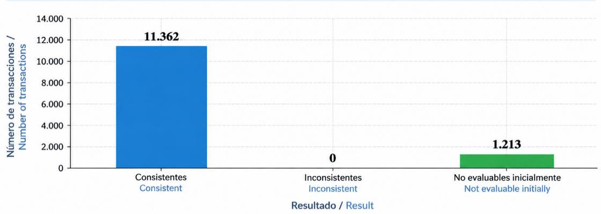

Figure 5.

Validation of the Relationship Between Unit Price, Quantity, and Total

Spending Using Business Rules.

Source.

Prepared by the author.

Figure

5

presents

the

results

of

validating

the

relationship

between

Price

Per

Unit,

Quantity,

and

Total

Spent

across

the

12,575

transactions

in

the

original

dataset.

Of

these,

11,362

records

(90.35%)

could

be

evaluated

and

satisfied

the

established

mathematical

r

elationship,

with

no

inconsistencies

identified

among

the

verifiable

transactions. However, 1,213 records (9.65%) could not initially be evaluated because

the information required to verify this relationship was missing. These findings support

the

applicat

ion

of

business

rules

to

recover

certain

missing

values,

although

the

observed consistency does not,

by itself, guarantee data accuracy. The non

-

evaluable

transactions

require

further

processing

to

determine

which

values

can

be

recovered

through deterministic procedures and which require statistical imputation methods.

8.

Missing Data Patterns

The missing data analysis identified four patterns of missing information in the original

dataset.

| Missing Data Pattern | Records |
| --- | --- |
| Complete records | 7.579 |
| Only Discount Applied missing | 3.783 |
| I tem + Price Per Unit missing | 609 |
| I tem + Quantity + Total Spent missing | 604 |
| Total | 12.575 |

Table 7.

Distribution

of Records by Missing Data Patterns in the Original Dataset.

Source.

Prepared by the author.

The analysis of missing data patterns identified four distinct situations across the 12,575

transactions in the original dataset. Of these, 7,579 records (60.27%) contain complete

information,

while

3,783

(30.08%)

have

missing

values

only

in

Discount

Appli

ed.

Additionally, 609 transactions (4.84%) have simultaneous

missing values in Item and

Price Per Unit, and another 604 (4.80%) lack information in Item, Quantity, and Total

Spent.

This

distribution

shows

that

missing

values

occur

in

specific

combinations

of

variables,

allowing

the

identification

of

joint

missingne

ss

patterns

and

guiding

deterministic

data

recovery

and

statistical

imputation

procedures.

However,

these

findings

alone

are

insufficient

to

determine

the

statistical

mechanism

underlying

the

missing data.

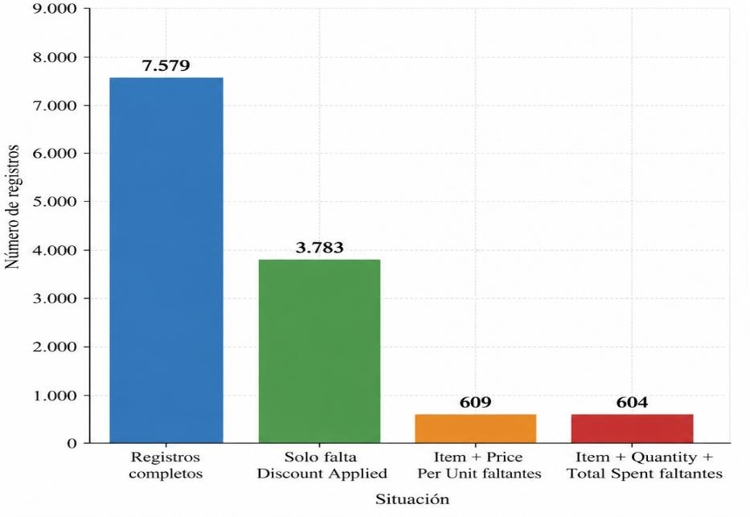

Figure 6.

Distribution of the Main Missing Data Patterns in the Original Dataset.

Source.

Prepared by the author.

Figure

6

shows the distribution of the main missing data patterns identified across

the 12,575 transactions. Complete records account for the largest proportion, with

7,579 observations (60.27%), followed by 3,783 transactions (30.08%) with missing

information

onl

y

in

Discount

Applied.

Additionally,

609

records

(4.84%)

have

simultaneous missing values in Item and Price Per Unit, while another 604 (4.80%)

contain missing values in Item, Quantity, and Total Spent. This distribution confirms

the presence of joint miss

ingness patterns in specific

variables, particularly those

related

to

products

and

the

monetary

values

of

transactions.

Identifying

these

patterns

helps

guide

the

application

of

business

rules

for

data

recovery

and

determine which records require further statistical assessment.

9.

Item Recovery

The first procedure used the relationship: Category + Price Per Unit → Item.

When this combination identified a unique product, the Item was retrieved.

| Stage | Items Recovered |
| --- | --- |
| First recovery | 604 |
| Second recovery | 609 |
| Total recovered | 1.213 |
| Remaining missing values | 0 |

Table 8.

Recovery of Missing Values in the Item Variable Through Deterministic

Procedures.

Source.

Prepared by the author.

Table

8

presents

the

results

of

the

missing

value

recovery

process

for

the

Item

variable, conducted in two stages. In the first stage, 604 records were recovered,

followed

by

an

additional

609

in

the

second

stage,

resulting

in

a

total

of

1,213

recovered va

lues. This procedure completed the Item information across all 12,575

transactions,

reducing

missing

values

from

1,213

(9.65%)

to

zero.

The

results

indicate

that

all

missing

values

were

recovered

using

the

applied

rules,

without

requiring statistical imput

ation for this variable. However, achieving complete data

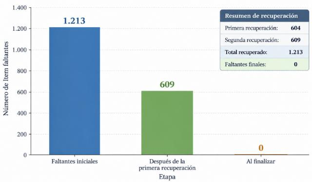

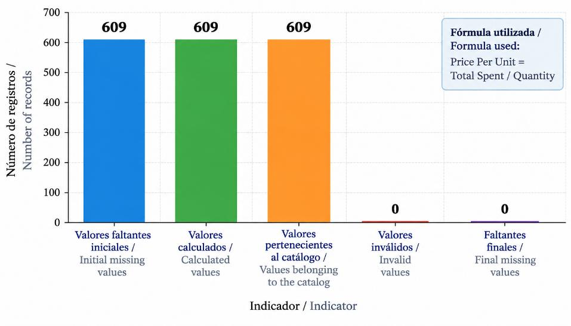

coverage does not, by itself, guarantee the accuracy of the recovered values, which

depends on the validity of the business rules used.

Figure 7.

Progressive Recovery of Missing Values in the Item Variable Through

Deterministic Procedures.

Source.

Prepared by the author.

Figure

7

illustrates the progressive reduction of missing values in the Item variable, which

initially contained 1,213 records with missing information (9.65% of the dataset). During

the first stage, 604 values were recovered, reducing the number of missing entrie

s to

609. Subsequently, following the recovery of Price Per Unit, the remaining 609 items

were identified, completely eliminating

missing values. This procedure achieved 100%

completeness in Item without requiring statistical imputation methods. These findings

illustrate the value of applying business rules sequentially, using information recovered

in

earlier

stages

to

support

subse

quent

recovery.

However,

the

validity

of

the

reconstructed

values

depends

on

the

consistency

and

verification

of

the

underlying

relationships.

10.

Price Per Unit Recovery

For the remaining 609 records without a price, Quantity and Total Spent were available.

Therefore: Price Per Unit = Total Spent / Quantity.

Figure 8.

Results of Missing Value Recovery in the Price Per Unit Variable Using

Business Rules.

Source.

Prepared by the author.

Figure

8

presents the results of recovering 609 missing values in the Price Per Unit

variable,

representing

4.84%

of

the

original

transactions.

Missing

unit

prices

were

[figure not shown]

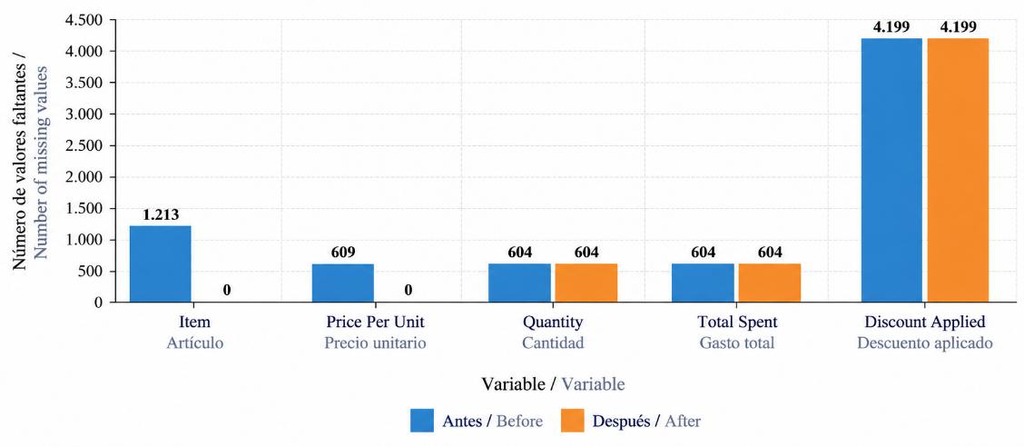

calculated

using

the

relationship

between

total

spending

(Total

Spent)

and

quantity

purchased (Quantity), yielding 609 values that were subsequently checked against the

valid price catalog. Validation confirmed that all recovered prices belonged to the set

of

permitted values, with no invalid results or remaining missing values after the procedure.

Consequently,

100%

completeness

was

achieved

for

this

variable

without

statistical

imputation. These findings support the application of business rules for data

recovery

when

relationships

between

variables

have

been

previously

verified,

although

membership in the valid price catalog alone does not guarantee the accuracy of each

reconstructed unit price.

11.

Results of Deterministic Data Cleaning

Después de aplicar las reglas de negocio, se evaluó la reducción de los valores faltantes

en cada variable. / After applying the business rules, the reduction in missing values was

assessed for each variable.

| Variable | Before | After | Recovered | Recovery Rate |
| --- | --- | --- | --- | --- |
| Item | 1.213 | 0 | 1.213 | 100 % |
| Price Per Unit | 609 | 0 | 609 | 100 % |
| Quantity | 604 | 604 | 0 | 0 % |
| Total Spent | 604 | 604 | 0 | 0 % |
| Discount Applied | 4.199 | 4.199 | 0 | 0 % |

Table 9.

Comparison of Missing Values Before and After Deterministic Data Cleaning.

Source.

Prepared by the author.

Table 9 presents the results of deterministic data cleaning by comparing missing values

before and after the procedure. All 1,213 missing values in Item and 609 in Price Per

Unit were recovered, achieving a 100% recovery rate for both variables. In contras

t,

Quantity and Total Spent retained their 604 missing values each, while Discount Applied

remained

incomplete

in

4,199

records.

These

findings

indicate

that

business

rules

successfully recovered all missing product and unit price information but were insu

fficient

to resolve missing values in the remaining variables. Therefore, the unresolved values

require further statistical assessment to determine whether imputation is appropriate,

considering the missingness patterns and available information.

Figure 9.

Comparison of Missing Values Before and After Deterministic Cleaning.

Source.

Prepared by the author.

Figure

9

shows two

bars

for

each

variable:

one

representing

the

number

of missing

values before cleaning and the other representing the number of missing values after

the process. This comparison shows that the reduction was complete for Item and P

rice

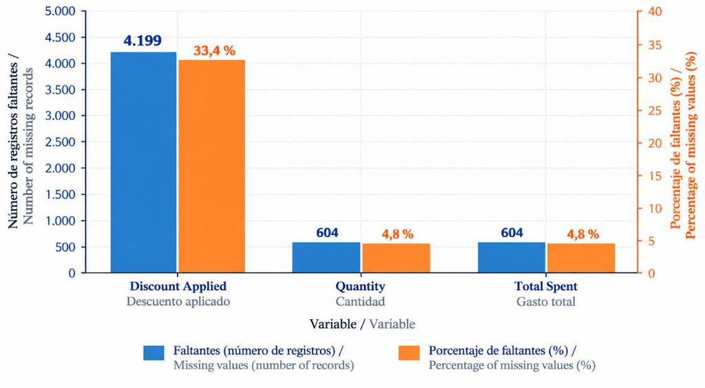

Per Unit. In Item, missing values decreased from 1,213 to 0, while in Price Per Unit, they

decreased from 609 to 0. In contrast, Quantity remained at 604 missing values, Total

Spent also remained at 604, and Discount Applied remain

ed at 4,199.

These results do not indicate a failure of the cleaning process. Instead, they show that

the

business

rules

applied

were

able

to

recover

only

those

values

that

could

be

reconstructed exactly and verifiably. In total, 1,822 deterministic transformations wer

e

performed, corresponding to the recovery of 1,213 values in Item and 609 in Price Per

Unit.

12.

Situation prior to statistical imputation

After the cleaning performed in Python, only three variables with missing data remained.

Figure 10.

Distribution of Missing Values Before Statistical Imputation.

Source.

Prepared by the author.

Figure 1

0

presents the missing values remaining after deterministic data cleaning

and

before

applying

statistical

imputation

procedures.

The

Discount

Applied

variable

accounts

for

the

largest

amount

of

missing

information,

with

4,199

records (33.4%), while Quantity

and Total Spent each contain 604 missing values

(4.8%). Together, these three variables account for 5,407 missing values. The

persistence

of

these

missing

values

indicates

that

the

applied

business

rules

could

not

recover

the

information

exactly,

making

i

t

necessary

to

assess

alternative statistical treatment methods.

In particular, imputing Quantity requires

considering its distribution and relationships with other variables, while handling

Total Spent must preserve consistency between unit price, quantity, and total

spending.

For

Discount

Applied,

the

available

inform

ation

must

be

evaluated

before determining whether statistical imputation is justified.

13.

Preparation for Quantity Imputation

To impute missing values in the Quantity variable, five predictors were selected:

Item,

Payment

Method,

Location,

year,

and

month.

These

variables

provide

information about the purchased product, payment method, purchase channel,

and temporal characteristi

cs of the transactions. The completeness assessment

confirmed that all five predictors were fully observed, with no missing values. This

allowed

them

to

be

included

in

the

imputation

procedure

without

requiring

additional

missing

data

treatment.

However,

t

heir

completeness

does

not

guarantee

predictive

performance,

making

it

necessary

to

assess

their

relationships with Quantity and the suitability of the selected statistical method.

[figure not shown]

14.

Construction of the Validation Sample

To evaluate imputation methods for the Quantity variable, a validation sample

was constructed by artificially masking originally observed values. Of the 11,971

records

with

available

information,

1,197

observations,

representing

approximately

10%,

were

sel

ected

and

temporarily

masked

to

assess

each

method's ability to recover known values. These cases were combined with the

604 originally missing values, resulting in a total of 1,801 records with missing

information

during

the

validation

procedure.

This

approach

allowed

imputed

quantities to be compared with the actual values of the masked observations,

providing

a

basis

for

measuring

imputation

error

and

selecting

the

best

-

performing method according to the established evaluation criteria. However, the

applicability of these results to genuinely missing observations depends on how

representative the validation sample is of re

cords with missing information.

Figure 11.

Validation Design for the Imputation of the Quantity Variable.

Source.

Prepared by the author.

Figure 1

1

shows the design used to validate the imputation methods applied to

the Quantity variable. Since it is not possible to calculate the error directly on the

604 truly missing records, because their actual values are unknown, a validation

strategy based on t

he temporary masking of observed data was used. In total,

the dataset contained 11,971 records with known Quantity values, of which 1,197

cases (10%) were artificially masked. Each imputation method then attempted to

reconstruct those values, and because t

he original values were known, it was

possible to compare the estimates with the real data and objectively measure the

imputation error. During this procedure, the 1,197 masked cases were added to

the 604 truly missing values, resulting in a total of 1,801

records without Quantity

information.

This

validation

design

made

it

possible

to

identify

the

best

-

performing imputation method before applying it to the genuinely missing cases.

15.

Comparison of Imputation Methods for Quantity

To select an imputation method for the Quantity variable, three alternatives were

evaluated:

Predictive

Mean

Matching

(PMM),

Classification

and

Regression

Trees

(CART),

and

Random

Forest.

The

comparison

was

conducted

using

artificially masked values during

validation and considering accuracy, prediction

error, and bias metrics.

PMM achieved an exact

-

match accuracy of 9.52%, which increased to 29.8%

when allowing deviations of up to one unit and to 47.5% with a tolerance of two

units. It also produced a mean absolute error (MAE) of 3.20, a root mean squared

error

(RMSE)

of

3.98,

a

nd

a

bias

of

-

0.016.

CART

achieved

an

exact

-

match

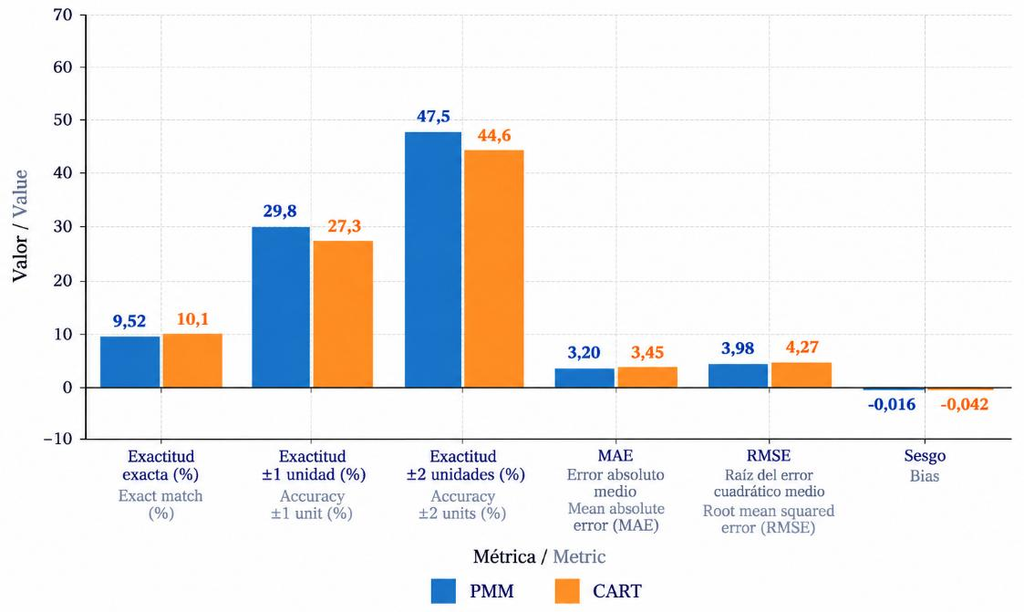

accuracy of 10.1%, slightly higher than PMM, representing a difference of 0.58

percentage

points.

Although

PMM

showed

more

favorable

results

on

the

e to CART and Random Forest. Overall, the results indicate

limited ability to recover the exact original quantities, although the near

-

zero bias

suggests

a

small

average

signed

deviation.

This

does

not

necessarily

imply

greater accuracy for individual pred

ictions; therefore, method selection should

consider error metrics alongside the distributional characteristics of the imputed

values.

F

igure 12.

Performance Comparison of Imputation Methods for the Quantity Variable.

Source.

Prepared by the author.

Figure 1

2

compares the performance of the imputation methods evaluated for the

Quantity

variable

using

accuracy,

error,

and

bias

metrics.

The

visualization

explicitly

displays

the

results

for

PMM

and

CART,

while

Random

Forest

was

included

in

the

overall

methodologi

cal

comparison

but

is

not

shown

in

the

displayed panel. Overall, the figure shows that none of the methods can perfectly

reconstruct

each

individual

Quantity

value.

However,

PMM

provides

the

best

overall

balance

between

accuracy,

error,

and

preservation

of

the

original

distribution.

Specifically, PMM achieved an exact

-

match accuracy of 9.52%, an accuracy of

29.8% within a margin of ±1 unit, and 47.5% within ±2 units. It also produced a

mean absolute error (MAE) of 3.20, a root mean squared error (RMSE) of 3.98,

and a bias of

-

0.016, w

hich is very close to zero. CART, in contrast, achieved a

slightly higher exact

-

match accuracy of 10.1%, but performed less favorably on

the remaining metrics, with lower accuracy within broader tolerance ranges and

higher

overall

prediction errors. Theref

ore, although

CART exactly

recovers a

slightly larger proportion of cases, PMM provides more stable overall behavior

and better preserves the structure of the data, making it the more appropriate

choice for the final imputation of Quantity.

[figure not shown]

16.

Preservation of the Quantity distribution

| Statistic | Observed | PMM |
| --- | --- | --- |
| Mean | 5,66 | 5,64 |
| Median | 6 | 6 |
| Standard deviation | 2,86 | 2,78 |
| Minimum | 1 | 1 |
| Maximum | 10 | 10 |

Table 10.

Comparison of Descriptive Statistics Between the Observed and

PMM

-

Imputed Distributions of Quantity.

Source.

Prepared by the author.

Table

1

0

.

Comparison

of

Descriptive

Statistics

for

Quantity

Between

Actual

Values and PMM

-

Imputed Values.

Table 1

0

compares the descriptive statistics of the Quantity variable between

actual values and those obtained using Predictive Mean Matching (PMM). The

0.02,

while

the

median

remai

ned

unchanged

at

6.

The

standard

deviation

decreased from 2.86 to 2.78, indicating slightly lower variability in the imputed

values.

The

minimum

and

maximum

values

remained

at

1

and

10

units,

respectively. These findings suggest that PMM approximately preserves the main

characteristics of the origi

nal distribution, although a slight reduction in variability

is

observed.

However,

similarity

in

descriptive

statistics

does

not

guarantee

preservation

of

the

entire

distribution

or

accuracy

at

the

individual

imputation

level.

Figure 13.

Comparison of the Observed Quantity Distribution with the PMM

-

Imputed Distribution.

Source.

Prepared by the author.

Figure 1

3

compares the observed distribution of the Quantity variable with the

distribution

obtained

using

Predictive

Mean

Matching

(PMM),

considering

the

displayed

frequencies

and

density

curves.

Both

distributions

exhibit

similar

shapes,

with

a

greater

of

observations

around

the

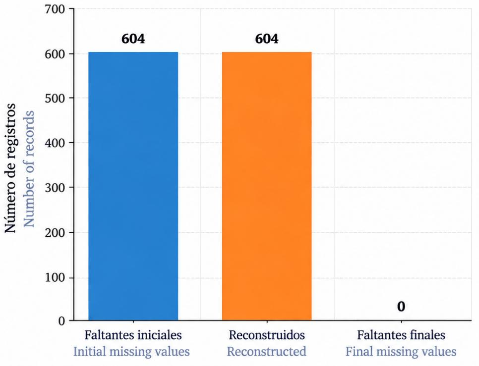

to

5.64

in

the

imputed

data,

while

the

median

remains

unchanged

at

6.

The

standard deviation decreases from 2.86 to 2.78, indicating a slight reduction in

variability, alth

ough the minimum and maximum values remain at 1 and 10 units.

These findings suggest that PMM reasonably preserves the main characteristics

of the original distribution. However, similarity between the two distributions does

not

guarantee

the

accuracy

of

i

ndividual imputations

and

should therefore

be

interpreted alongside the error metrics obtained during validation.

17. Reconstruction of Total Spent

After

completing

the

imputation

of

Quantity

using

Predictive

Mean

Matching

(PMM),

the

missing

values

in

Total

Spent

were

reconstructed

using

the

mathematical relationship between unit price and quantity purchased:

Total Spent

=

Price Per Unit

×

Quantity

This procedure calculated all 604 missing values in Total Spent, reducing the

number of missing entries from 604 to zero and achieving 100% completeness.

No additional statistical method was required for this variable, as the transaction

amounts were calcu

lated directly from Price Per Unit and the imputed Quantity

values. However, although the reconstruction is deterministic, the results depend

on

quantities

previously

estimated

using

PMM

and

therefore

retain

the

uncertainty associated with that imputation.

Consequently, complete recovery of

Total

Spent

ensures

consistency

with

the

applied

formula

but

does

not

necessarily guarantee the accuracy of the reconstructed amounts relative to the

unknown original values.

Figure 14.

Recovery of Missing Values in Total Spent.

Source.

Prepared by the author.

Figure 1

4

shows the treatment applied to the Total Spent variable after the imputation

of Quantity. Initially, this variable contained 604 missing values. Once the Quantity

values

were

obtained,

it

was

possible

to

reconstruct

all

604

missing

Total

Spent

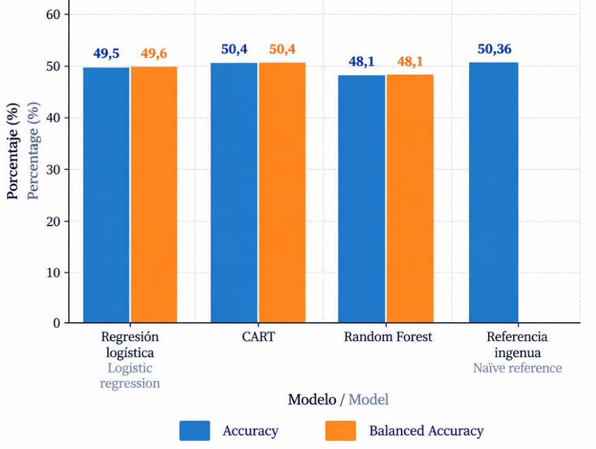

records

using

the

mathematical

relationship

between

unit

price

and

quantity

purchased, so no missing values remained at the end of the process.

This result indicates that it was not necessary to build an additional statistical model

for Total Spent. Instead, total spending was calculated directly by multiplying Price

Per Unit by Quantity, allowing the use of a verifiable business rule and avoiding

a

second statistical imputation for a variable that depends on another already treated.

However, it should be noted that the reconstructed Total Spent values depend on

the

previously

imputed

values

of

Quantity.

Therefore,

although

the

mathematical

operation

used

for

reconstruction

is

exact,

the

final

result

indirectly

retains

the

uncertainty associated with the imputation of Quantity.

18.

Evaluation of Discount Applied

The Discount Applied variable contained 4,199 missing values, representing 33.39%

of the transactions in the original dataset. To assess whether these values could be

imputed, three supervised classification models were compared: logistic regression,

Class

ification

and

Regression

Trees

(CART),

and

Random

Forest.

Model

performance was evaluated using overall accuracy and balanced accuracy, with a

naive classifier achieving 50.36% accuracy as the reference.

The

results

showed

that

CART

achieved

the

highest

performance

among

the

evaluated models, with an accuracy of 50.4% and a balanced accuracy of 50.4%.

Logistic regression achieved 49.5% accuracy and 49.6% balanced accuracy, while

Random Forest recorded 48.1

% on both metrics. Although CART performed slightly

better, its improvement over the baseline classifier was only 0.04 percentage points.

This

indicates

that

none

of

the

models

achieved

a

meaningful

improvement

in

predictive performance compared with

the reference.

Consequently,

the

results

do

not

provide

sufficient

evidence

to

justify

imputing

Discount Applied using the evaluated models. Assigning values based on predictions

with this level of performance could introduce classification errors and distort the

origina

l variable distribution. Therefore, retaining the missing values, documenting

their presence, and avoiding imputations without sufficient predictive support is the

more methodologically appropriate approach.

Figure 15.

Comparison of Predictive Performance of Classification Models for

the Discount Applied Variable.

Source.

Prepared by the author.

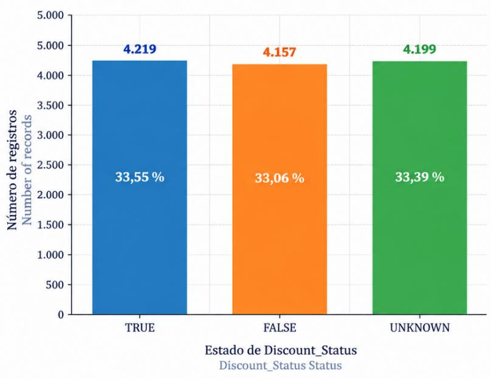

Figure 1

5

presents the performance of logistic regression, CART, and Random

Forest models using accuracy and balanced accuracy metrics. CART achieved

the

highest

accuracy

at

50.4%,

followed

by

logistic

regression

at

49.5%

and

Random

Forest

at

48.1%.

However,

CART

e

xceeded

the

baseline

classifier,

which achieved 50.36% accuracy by assigning cases to the majority class, by

only

0.04

percentage

points.

Balanced

accuracy

also

remained

close

to

50%

across

all

three

models,

indicating

limited

ability

to

distinguish

betwee

n

transactions with and without discounts. These findings do not provide sufficient

evidence

to

reliably

impute

the

4,199

missing

values

in

Discount

Applied.

Consequently,

these

values

were

retained

as

unknown

rather

than

assigning

TRUE or FALSE labels wit

hout adequate predictive support.

19.

Creation of Discount_Status

Given the limited predictive performance of the models evaluated for Discount

Applied, the decision was made to retain the missing values and create a new

variable

named

Discount_Status,

with

three

categories:

TRUE,

FALSE,

and

UNKNOWN.

This

classification

distinguishes

transactions

with

discounts,

transactions without discounts, and those for which insufficient information was

available to determine their status. The results show that 4,219 records (33.55%)

were

classified

as

TRUE,

4,157

(33.06%) as

FALSE,

and

4,199

(33.39%) as

UNKNOWN,

accounting

for

all

12,575

transactions.

The

distribution

shows

similar proportions across the three categories, although UNKNOWN represents

unobserved information rather than a third

actual discount status. This approach

preserved

the

uncertainty

associated

with

the

original

records,

avoided

imputations without sufficient predictive support, and enabled missing information

to be handled explicitly in subsequent analyses.

Figure 16.

Distribution of the Discount_Status Variable in the Final Dataset.

Source.

Prepared by the author.

Figure 1

6

shows the distribution of the Discount_Status variable, created to explicitly

preserve

both

observed

and

missing

information

regarding

discount

application.

The

results indicate that 4,219 records (33.55%) were classified as TRUE, 4,157 (33.06%)

as FALSE,

and 4,199 (33.39%) as UNKNOWN. The three categories are very similar in

size, each representing approximately one third of the 12,575 transactions.

It is important to note that the UNKNOWN category does not mean that no discount was

applied.

Its

meaning

is

different:

it

indicates

that

there

is

insufficient

information

to

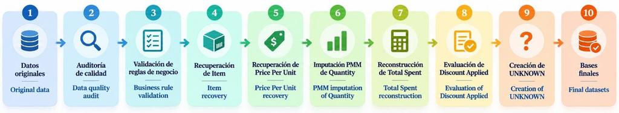

determine whether a discount was applied or not. In this way, the variable distinguishes

between

known

observations

and

observations

for

which

information

is

unavailable,

avoiding unsupported imputations and explicitly preserving the uncertainty present in

the

original data.

20. Resultado general del tratamiento de los datos faltantes / Overall Results of

Missing Data Treatment

| Variable | Faltantes iniciales / Initial Missing Values | Tratamiento / Treatment | Resultado / Result |
| --- | --- | --- | --- |
| Item | 1.213 | Deterministic recovery | 0 missing values |
| Price Per Unit | 609 | Deterministic reconstruction | 0 missing values |
| Quantity | 604 | PMM imputation | 0 missing values |
| Total Spent | 604 | Mathematical reconstruction | 0 missing values |
| Discount Applied | 4.199 | No se imputa / No imputation | 4,199 missing values |
| Discount_Status | — | T RUE/FALSE/UNKNOWN classification | 0 missing values |

Table 11.

Summary of Strategies Applied for Missing Data Treatment.

Source.

Prepared by the author.

Table

1

1

summarizes

the

results

of

missing

data

treatment

through

deterministic

procedures, statistical imputation, and explicit preservation of unknown information. A

total of 1,213 missing values in Item and 609 in Price Per Unit were recovered using

business ru

les, while the 604 missing values in Quantity were estimated using Predictive

Mean

Matching

(PMM).

Subsequently,

604

missing

values

in

Total

Spent

were

reconstructed

using

the

mathematical

relationship

between

unit

price

and

quantity,

although these calcul

ations retain the uncertainty associated with the imputed quantities.

In contrast, the 4,199 missing values in Discount Applied were left unimputed because

of

the

limited

predictive

performance

of

the

evaluated

models.

To

facilitate

their

treatment,

Discount_Status

was

created

to

distinguish

between

applied

discounts

(TRUE), unapplied discounts (FALSE), and unknown information (UNKNOWN). Overall,

the process achieved complete coverage for four of the five originally affected variables

while explicitly preserving mis

sing information in the remaining variable. This approach

avoided assigning unsupported values and maintained a distinction between recovered

data, statistically estimated values, and information that remained unknown.

Figure 17.

Methodological Workflow for Data Auditing, Cleaning, Recovery, and Imputation.

Source.

Prepared by the author.

Figure 1

7

illustrates the ten stages of the data processing workflow applied to the

Retail Store Sales: Dirty for Data Cleaning dataset. The process began with a data

quality audit and business rule validation, which enabled the recovery of missing

values

in

Item

a

nd

Price

Per

Unit

through

deterministic

relationships.

Predictive

Mean Matching (PMM) was subsequently used to impute missing Quantity values,

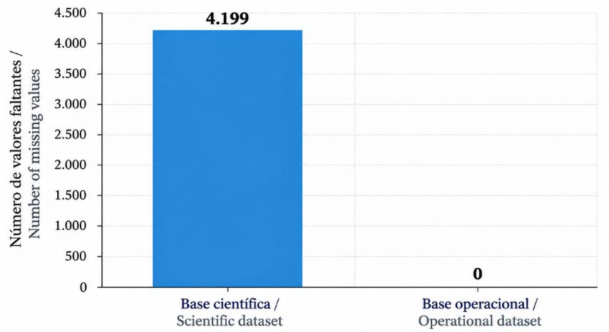

followed by the reconstruction of Total Spent using the relationship between unit

price and quantity purchased. The next stage assessed the feasibility of imputing

Discount Applied, but the limited predictive performance of the evaluated models

supported r

etaining its missing values through the UNKNOWN category in the new

Discount_Status

variable.

Finally,

the

processed

datasets

were

obtained,

maintaining

a

distinction

between

observed,

recovered,

imputed,

and

unknown

values. This workflow documented the transformations performed and preserved the

traceability of the data t

reatment process.

21. Bases de datos finales / Final Datasets

| Characteristic | Scientific Dataset | Operational Dataset |
| --- | --- | --- |
| Records | 12.575 | 12.575 |
| Variables | 14 | 13 |
| Missing values | 4.199 | 0 |
| Retains Discount Applied | Sí / Yes | No |
| Retains Discount_Status | Sí / Yes | Yes |
| Recommended use | Research and reproducibility | Reporting and operational analysis |

Table 12.

Comparison of the Characteristics of the

Final Datasets.

Source.

Prepared by the author.

Table

12

presents the characteristics of the two datasets generated after completing

the cleaning and imputation process. Both retain all 12,575 original transactions but

differ

in

the

number

of

variables

and

the

treatment

of

missing

information.

The

scientific da

taset contains 14 variables and preserves the 4,199 missing values in

Discount Applied, along with the Discount_Status

variable, which explicitly identifies

records with unknown information. This structure maintains the distinction between

observed

and

unavailable

values,

making

it

suitable

for

research

requiring

traceability

and

reproducibility.

In

contrast,

the

operatio

nal

dataset

contains

13

variables and has no missing values because it excludes Discount Applied while

retaining Discount_Status

with the categories TRUE, FALSE, and UNKNOWN. This

version facilitates reporting and operational analysis, provided that the UNKNOWN

category is interpreted as unavailable information rather than as an indication that

no discount was applied.

Figure 18.

Comparison of Missing Values Between the Scientific and Operational

Datasets.

Source.

Prepared by the author.

Figure

18

shows the difference in the number of missing values between the two

datasets

generated

after

the

cleaning

and

imputation

process.

The

scientific

dataset

retains

4,199

missing

values,

corresponding

exclusively

to

Discount

Applied, while the operational da

taset contains no missing values because this

variable was excluded. Both datasets preserve all 12,575 original transactions

and retain Discount_Status

, which identifies records with unknown information.

This

difference

reflects

the

intended

purpose

of

each

dataset:

the

scientific

dataset

explicitly

preserves

unobserved

values

to

support

traceability

and

reproducibility, whereas the operational dataset p

rovides a structure without null

values

for

reporting

and

operational

analysis.

However,

the

absence

of

null

values in the operational dataset does not mean that all original information was

recovered, since the 4,199 unknown cases remain explicitly identi

fied through the

UNKNOWN category.

22.

Overall Process Summary

| Process | Records Processed |
| --- | --- |
| Items recovered deterministically | 1.213 |
| Unit prices recovered deterministically | 609 |
| Deterministic transformations in Python | 1.822 |
| Quantity values imputed using PMM | 604 |
| Total Spent values reconstructed | 604 |
| Discount Applied values retained as unknown | 4.199 |
| Records deleted | 0 |

Table 21.

Final Summary of the Main Transformations Performed During Data

Auditing, Cleaning, and Imputation.

Source.

Prepared by the

author.

Note:

The

1,822

deterministic

transformations

represent

the

sum

of

1,213

recovered Item values and 609 recovered Price Per Unit values; they are not an

additional group.

Table

21

summarizes

the

main

transformations

performed

during

the

dataset

auditing,

cleaning,

and

imputation

process.

In

the

Python

stage,

1,822

deterministic recoveries were completed, including 1,213 values in Item and 609

in Price Per Unit. Subsequently

, 604 missing Quantity values were imputed using

Predictive Mean Matching (PMM), enabling the mathematical reconstruction of

604 missing values in Total Spent. In contrast, the 4,199 records with missing

Discount Applied information were retained as unknow

n because of the limited

predictive

performance

of

the evaluated

models.

The

process

was

completed

without deleting any of the 12,575 original transactions, maintaining a distinction

between recovered, statistically estimated, and unobserved values. These

results

indicate

that

the

procedure

improved

data

completeness

without

introducing

imputations that lacked sufficient empirical support.

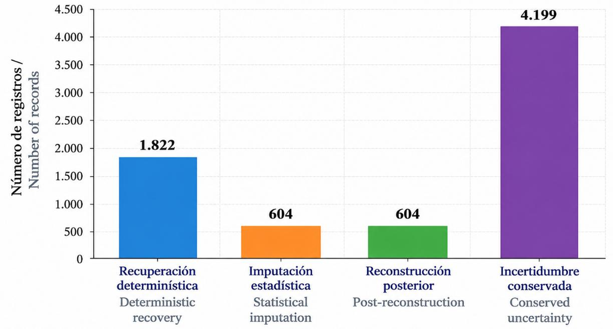

Figure 19.

Distribution of Treated Values by Procedure Applied During Data

Cleaning and Imputation.

Source.

Prepared by the author.

Figure

19

presents

the

number

of

values

treated

according

to

the

procedure

applied during dataset cleaning and imputation. The largest group corresponds

to

Discount

Applied,

with

4,199

values

retained

as

unknown

because

of

insufficient predictive evidence to justif

y their imputation. During data cleaning,

1,822 deterministic recoveries were performed for the Item and Price Per Unit

variables.

Subsequently,

604

missing

Quantity

values

were

imputed

using

Predictive

Mean

Matching

(PMM),

and

another

604

Total

Spent

valu

es

were

mathematically reconstructed from the imputed quantities. These findings show

that data treatment focused on distinguishing information recoverable through

business rules, values requiring statistical estimation, and information that should

remain

unknown. It should be noted that these figures represent values treated

by variable rather than necessarily distinct transactions, since a single transaction

may have required more than one procedure.

23.

Conclusions

The data auditing, cleaning, and imputation process applied to the Retail Store

Sales:

Dirty

for

Data

Cleaning

dataset

improved

data

completeness

while

preserving all 12,575 original transactions, without deleting any records during

processing. The methodo

logy combined business rules implemented in Python

with statistical procedures developed in R, prioritizing deterministic recovery and

reserving imputation for values that could not be reconstructed exactly.

Deterministic cleaning recovered all 1,213 missing values in Item and 609 in Price

Per

Unit,

resulting

in

1,822

recoveries.

These

findings

show

that

verified

relationships

between

variables

can

be

used

to

address

data

completeness

issues without relying on

statistical estimation. However, the validity of recovered

values depends on the applicability of the business rules and the consistency of

the information used.

For the 604 missing values in Quantity, PMM, CART, and Random Forest were

compared through a validation procedure based on artificially masking known

observations. PMM showed the most favorable overall performance according to

the evaluated criteria, with

a mean absolute error (MAE) of 3.20 units, a root

mean

squared

error

(RMSE)

of

3.98,

and

a

bias

of

−0.016.

Additionally,

the

imputed distribution exhibited characteristics similar to

the observed distribution,

selection of PMM, individual imputation accuracy remained limited, indicating that

estimated values should be interpreted in light of the uncertaint

y associated with

the procedure.

After imputing Quantity, the 604 missing values in Total Spent were reconstructed

using the mathematical relationship between unit price and quantity purchased.

This decision avoided applying a second statistical model to a variable directly

related

to

ano

ther

that

had

already

been

estimated.

Nevertheless,

the

reconstructed amounts retain the uncertainty associated with the imputation of

Quantity, even though the calculations are mathematically consistent.

The evaluation of Discount Applied showed that the classification models had

limited predictive ability, with accuracy ranging from 48.1% to 50.4%, close to the

50.36% achieved by the baseline classifier. Given the lack of sufficient predictive

improvement

, the decision was made not to impute the 4,199 missing values in

this

variable.

Instead,

Discount_Status

was

created,

incorporating

the

UNKNOWN

category

to

identify

records

whose

discount

status

remains

unknown.

This

decision

avoided

introducing

artificial

classifications

without

adequate empirical support.

As a result, two final datasets were generated: a scientific dataset containing 14

variables, which explicitly preserves missing values in Discount Applied, and an

operational dataset containing 13 variables, with no null values but with unknown

informatio

n

identified

through

Discount_Status

.

Both

retain

all

12,575

original

transactions

and

support

different

research

and

operational

analysis

requirements.

In

conclusion,

the

main

methodological

outcome

of

the

project

was

the

development of a procedure that distinguishes originally observed values, values

recovered

through

deterministic

rules,

statistically

estimated

values,

and

information

that

remains

unkno

wn.

This distinction

supports documentation

of

data

provenance,

recognition

of

imputation

limitations,

and

prevention

of

the

assumption

that

greater

completeness

necessarily

implies

greater

accuracy.

Therefore,

the

quality

of

the

final

datasets

depends

bot

h

on

the

information

recovered

and

on

the

transparency

with

which

estimates

and

remaining

uncertainty are documented.